# German ideophone dataset

Aleksandra Ćwiek

2025-03-27

# Introduction

This is the updated and functional version of the German ideophone dataset, originally collected from February to August 2018 in the Helene-Nathan library in Berlin. The database was collected by Aleksandra Ćwiek and Luisa Cimander (during her internship at ZAS). A more detailed description is provided in (Ćwiek 2022), Chapter 4.2. Below, I will give excerpts of this work.

This work was published as a dataset in Ćwiek, Aleksandra (2025). A dataset of German ideophones from children’s books. *Linguistische Berichte*. [DOI](https://doi.org/10.46771/9783967699470_3)

Please use the appropriate citation form when using this dataset.

## Excerpt from Ćwiek (2022) on data collection

The criteria for the data collection are attributable to the key elements of what an ideophone is, as discussed above, and based on the theory by Dingemanse (2019), 16. Words with sound-symbolic ideophone-like features were not treated as ideophones if they showed morphosyntactic integration (Dingemanse 2012a, 656). In that sense, verbs that remind of ideophones, such as *krächzen* from *krächz* ‘croak’ or *piepen* from *piep* ‘squek,’ were not included in the data set (cf. also Chapter 4.2). Similarly, nouns that bear signs of declension were excluded from the data set. As shown by Dingemanse (2017) and Dingemanse and Akita (2016), morphosyntactic integration and the expressive character of ideophones are inversely correlated. Hence, only nouns that were not morphosyntactically integrated, i.e., not declined as well as marked, were incorporated in the data set. Each instance of the ideophone was entered into the data set. Also, the original form of the ideophones was kept, e.g., *ahuuuuuuuuuuuuuuuuuuuuuuuuuuuuuuuuuuuuuuuuuuu*, or *huuuaaaaaaaaah*, in order to allow for an analysis of prosodic amplification in the future (similar to, e.g., Fuchs et al., 2019, for adjective antonym pairs). However, a unified written form was noted beside the original one, e.g., *ahu*, or *huah* for the above, which allows for comparing the number of word forms (original forms as seen in the book) with the number of base forms (unified forms as would be seen in a dictionary).

Next, we collected metadata on the book, in which a given ideophone was found, such as the title, the author, the age recommendation, the original language, and the publishing year. We hope that this metadata might allow for testing other effects in the future, for example, whether the language of origin has an influence on the variability and the number of ideophones in the book (original language), or whether the use of ideophones in children’s books changes over time (publishing year).

The data set also entails the context of the ideophone and its meaning in context, if possible to establish. The interpretation of the meaning in context is subjective and might be a case for an in-depth investigation in the future. A photo was taken of the page on which the ideophone was found to ease future work with ideophones in context. In this respect, photos are a part of the data set. The unique name of each photo for a given page, on which the ideophone was found, is noted in the data set. Two other columns are the part of speech and category, yet, these are by far the least developed parts of the data set so far. An idea for future research might be to comprehensively structure ideophones for a German ideophone dictionary by parts of speech, but also across the categories in which ideophones may fall, such as sound, movement, or texture ideophones [Dingemanse (2012b), 663; McLean (2020), 18; and Chapter 4.4].

Lastly, the data set comprises the information on the number of words on a given page and the number of pages in a given book. The former was extracted semiautomatically using picture-to-text recognition available in Microsoft OneNote (Microsoft Corporation, 2018). In the cases that the text was not recognized correctly, the number of words was counted manually. This situation occurred, e.g., when the picture quality was worse and when the text was written by hand or not horizontally from left to right. A word was treated as an orthographic unit between two blank spaces with a few exceptions. In some cases, ideophones were concatenated into one word, e.g., *oh je*, *ach herrje*, or *tra, ri, ra*. Those examples concern ideophones, which often co-occur and are officially written separately which, however, tend to be concatenated in informal writing – compare *oh je* with 19,959 vs. *ohje* with 15,624 occurrences, as given in theWebXL corpus of the DWDS (“DWDS Digitales Wörterbuch der deutschen Sprache,” n.d., accessed on February 5, 2021). All words were counted, even those written on the graphic elements and which were merely elements of the story; see Figure 4.2 for an example. In some cases, the pictures did not comprise the whole page, i.e., parts of the text were cut out. Then, an estimation of the word count, based on the visible parts and other available pages, was given. The number of pages was copied from the library database. The number of words on a page, along with the age recommendation data, allows for testing the hypothesis, whether there are more ideophones in books for younger audiences (cf. Chapter 4.5).

## Dataset description

The script below is used to translate to English and explore the existing dataset. The columns of the dataset called `german_ideophone_dataset.csv` created at the end of this markdown file are as follows:

- **ID**: A unique identifier for each entry in the dataset.
- **Ideophone**: The ideophone as it appears in the book, including its full original form.
- **BaseForm**: The simplified or standardized form of the ideophone used for analysis.
- **BookTitle**: The title of the book where the ideophone was found.
- **Author**: The author(s) of the book where the ideophone was found.
- **AgeRating**: The recommended age range for the book, as specified by the publisher.
- **AgeGroup**: A grouped version of the age rating, where:
  - `1` represents younger children (e.g., 0-6 years old).
  - `2` represents older children (e.g., 7-9 years old).
- **OriginalLanguage**: The language in which the book was originally published.
- **Year**: The year the book was published.
- **Context**: A snippet of the text where the ideophone appears, providing its context.
- **MeaningInContext**: The interpreted meaning of the ideophone within its context, based on the collector’s analysis.
- **Source**: An identifier or reference to the source where the ideophone was collected.
- **WordType**: The grammatical word type or part of speech of the ideophone, if applicable (e.g., noun, verb).
- **WordCount**: The total number of words on the page where the ideophone appears.
- **PageCount**: The total number of pages in the book where the ideophone appears.
- **FrequencyRank**: The rank of the base form according to the frequency of occurrence across the dataset.

```r
########## folders ##########
library(here)

parentfolder <- dirname(getwd())
data          <- paste0(parentfolder, '/ideophoneData/')
hierarchy     <- paste0(parentfolder, '/hierarchyData/')
photos        <- paste0(parentfolder, '/bookPhotos/')
plots         <- paste0(parentfolder, '/plots/')
scripts       <- paste0(parentfolder, '/scripts/')
models       <- paste0(parentfolder, '/models/')

########## source file ##########

#source(paste0(scripts, "adjectives-preparation.R"))

#################### packages ####################
library(tibble)
library(stringr)
library(readr)    # data wrangling
library(tidyr)
library(dplyr)
library(ggplot2) # plotting
library(ggpattern) # remotes::install_github("coolbutuseless/ggpattern")
library(tidyverse)
library(ggpubr)
library(gridExtra)
library(BayesFactor)
library(brms)

colorBlindBlack8  <- c("#000000", "#E69F00", "#56B4E9", "#009E73",
                       "#F0E442", "#0072B2", "#D55E00", "#CC79A7")
```

# Import data

```r
df = read.csv(paste0(data, 'Korpus_Ideophone.csv'), sep=';', na.string = "NA", encoding="UTF-8")
```

# Clean and prepare

Translate to English where possible.

```r
str(df)
```

```
## 'data.frame':    3631 obs. of  15 variables:
##  $ ID                  : int  107 131 713 223 1246 1240 1478 1807 2326 865 ...
##  $ Ideophon            : chr  "(allez) hopp" "(im) zickzack" "ä-ä-ä-ä" "ääääää" ...
##  $ Grundform           : chr  "hopp" "zickzack" "äää" "äää" ...
##  $ Buchtitel           : chr  "Ich bin der kleine Mutiger" "Achtung Ziesel!" "Die Böckchen-Bande im Schwimmbad" "Lisa wartet auf den Bus" ...
##  $ Autor               : chr  "Günther Jakobs" "Helga Bansch" "Björn F. Rörvik, Gry Moursund" "Sven Nordqvist" ...
##  $ Alterseinstufung    : chr  "1,2" "1,2" "bis 6" "bis 6" ...
##  $ Altersgruppe        : int  1 1 1 1 1 1 1 1 2 1 ...
##  $ Originalsprache     : chr  "Deutsch" "Deutsch" "Norwegisch" "Schwedisch" ...
##  $ Jahr                : chr  "2016" "2017" "2017" "2011" ...
##  $ Kontext             : chr  "Eine Kleinigkeit für mich! Ich bin Mutiger! Allez hopp!" "\"Sssssss!\" , soll dann die Gelse im Zickzack um das Ziesel schwirren." "\"Ä-ä-ä-ä\", meckerte das kleinste Böckchen." "-0" ...
##  $ Bedeutung.im.Kontext: chr  "Springgeräusch." "Richtungsangabe?" "Meckern?" "Pfeifgeräusch von Grashalmen." ...
##  $ Quelle              : chr  "13_KM_07" "16_AZ_11" "130_BB_11" "35_LB_03" ...
##  $ Wortart             : chr  "" "Substantiv?" "" "" ...
##  $ Wortanzahl          : int  24 45 20 57 65 45 103 41 24 14 ...
##  $ Seitenzahl          : int  32 32 48 32 28 28 36 32 80 32 ...
```

```r
# Renaming columns
colnames(df) <- c("ID", "Ideophone", "BaseForm", "BookTitle", "Author", "AgeRating",
                  "AgeGroup", "OriginalLanguage", "Year", "Context",
                  "MeaningInContext", "Source", "WordType", "WordCount", "PageCount")

# Translating OriginalLanguage
df$OriginalLanguage <- recode(df$OriginalLanguage,
    "Deutsch" = "German",
    "Norwegisch" = "Norwegian",
    "Schwedisch" = "Swedish",
    "Französisch" = "French",
    "Englisch" = "English",
    "Niederländisch" = "Dutch",
    "Spanisch" = "Spanish",
    "Tschechisch" = "Czech",
    "Japanisch" = "Japanese",
    "Hebräisch" = "Hebrew",
    "Estnisch" = "Estonian",
    "Polnisch" = "Polish",
    "Deutsch?" = "German",
    "Türkisch" = "Turkish",
    "Georgisch" = "Georgian",
    "Koreanisch" = "Korean",
    "Dänisch" = "Danish",
    "Persisch" = "Farsi",
    "?" = "Unknown",
    "Finnisch" = "Finnish"
)
```

# Frequencies

## Ideophone counts

How many unique ideophones are there?

```
##   UniqueIdeophones
## 1             1020
```

How often do unique ideophones occur?

```
## # A tibble: 20 × 2
##    Ideophone Frequency
##    <chr>         <int>
##  1 na              220
##  2 oh              157
##  3 ach             143
##  4 tak              58
##  5 oje              53
##  6 he               50
##  7 platsch          49
##  8 äh               41
##  9 oh nein          36
## 10 hm               35
## 11 na gut           35
## 12 puh              31
## 13 aha              30
## 14 na ja            28
## 15 hurra            27
## 16 nanu             27
## 17 ah               25
## 18 hmm              24
## 19 hopp             24
## 20 hui              23
```

How many base forms are there?

```
##   BaseForms
## 1       650
```

How often do the base forms occur?

```
## # A tibble: 20 × 4
##    BaseForm Frequency FrequencyRank PercentageOfTotal
##    <chr>        <int>         <int>             <dbl>
##  1 na             228             1             6.28
##  2 oh             187             2             5.15
##  3 ach            145             3             3.99
##  4 hm              71             4             1.96
##  5 oje             65             5             1.79
##  6 tak             58             6             1.60
##  7 he              53             7             1.46
##  8 ah              51             8             1.40
##  9 platsch         50             9             1.38
## 10 ohnein          44            10             1.21
## 11 äh              43            11             1.18
## 12 pst             41            12             1.13
## 13 nagut           36            13             0.991
## 14 hui             34            14             0.936
## 15 puh             34            15             0.936
## 16 naja            33            16             0.909
## 17 bäh             32            17             0.881
## 18 aha             31            18             0.854
## 19 hopp            31            19             0.854
## 20 hurra           29            20             0.799
```

Arguably, some of those are possibly not ideophones. I do not remove them here, but any future research needs to possibly select those words that are useful to them.

Let us plot top 30 base form ideophones.

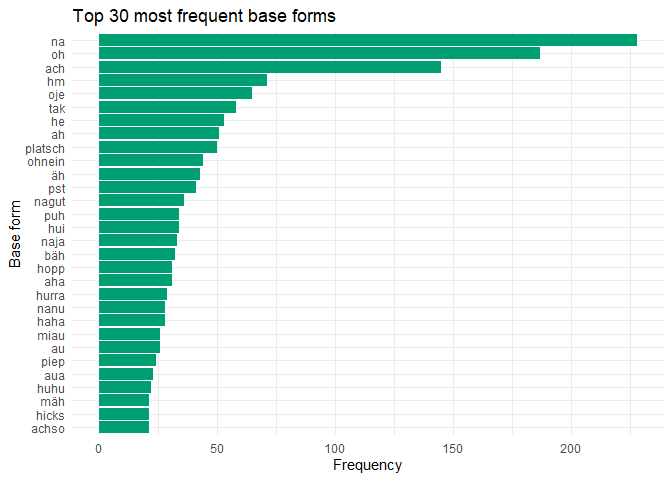

Now as percentage instead of raw numbers.

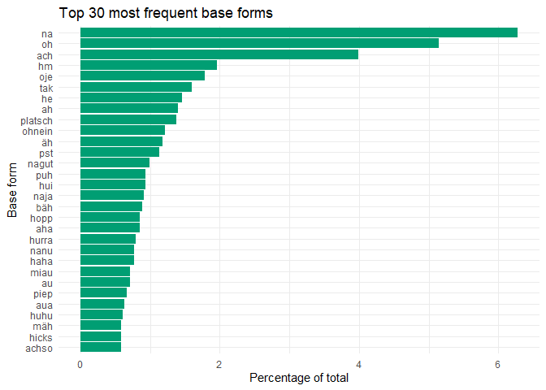

```r
ggplot(top_ideophones, aes(x = reorder(BaseForm, Frequency), y = PercentageOfTotal)) +
  geom_bar(stat = "identity", fill = colorBlindBlack8[4]) +
  coord_flip() +
  labs(title = "Top 30 most frequent base forms",
       x = "Base form",
       y = "Percentage of total") +
  theme_minimal()
```

```r
# Save the plot
ggsave(plot = last_plot(), filename = paste0(plots, "top30MostFrequent_percentage.pdf"),
       width = 6, height = 6)
ggsave(plot = last_plot(), filename = paste0(plots, "top30MostFrequent_percentage.jpg"),
       width = 6, height = 6)
ggsave(plot = last_plot(), filename = paste0(plots, "top30MostFrequent_percentage.tif"),
       width = 6, height = 6, compression = "lzw", dpi = 600)
```

How many occur only once (*hapax legomena*) and how many more than once?

```r
baseform_freq %>%
  summarise(
    once_count = sum(Frequency == 1),
    more_than_once_count = sum(Frequency > 1),
    total_count = n()
  ) %>%
  pivot_longer(cols = c(once_count, more_than_once_count),
               names_to = "Occurrence",
               values_to = "Number") %>%
  mutate(
    Percentage = (Number / total_count) * 100
  ) %>%
  select(Occurrence, Number, Percentage)
```

```
## # A tibble: 2 × 3
##   Occurrence           Number Percentage
##   <chr>                 <int>      <dbl>
## 1 once_count              307       47.2
## 2 more_than_once_count    343       52.8
```

Extract ten most and ten least frequent base forms.

```r
set.seed(123)

top_flop_10 <- baseform_freq %>%
  slice_max(Frequency, n = 10) %>%
  bind_rows(
    baseform_freq %>%
      filter(Frequency == 1) %>%
      slice_sample(n = 10)
  ) %>%
  mutate(
    PercentageOfTotal = sprintf("%.2f%%", (Frequency / sum(baseform_freq$Frequency)) * 100)
  ) %>%
  select(FrequencyRank, BaseForm, Frequency, PercentageOfTotal) %>%
  arrange(FrequencyRank)

knitr::kable(
  top_flop_10,
  col.names = c("Rank", "Base form", "Frequency", "% of total"),
  format = "pipe"
)
```

| Rank | Base form | Frequency | % of total |
| --- | --- | --- | --- |
| 1 | na | 228 | 6.28% |
| 2 | oh | 187 | 5.15% |
| 3 | ach | 145 | 3.99% |
| 4 | hm | 71 | 1.96% |
| 5 | oje | 65 | 1.79% |
| 6 | tak | 58 | 1.60% |
| 7 | he | 53 | 1.46% |
| 8 | ah | 51 | 1.40% |
| 9 | platsch | 50 | 1.38% |
| 10 | ohnein | 44 | 1.21% |
| 357 | bam | 1 | 0.03% |
| 433 | hoi | 1 | 0.03% |
| 461 | klang | 1 | 0.03% |
| 496 | matsche | 1 | 0.03% |
| 522 | pardauz | 1 | 0.03% |
| 538 | plum | 1 | 0.03% |
| 572 | ruck | 1 | 0.03% |
| 587 | schlörf | 1 | 0.03% |
| 642 | zickzackzorn | 1 | 0.03% |
| 649 | öhöm | 1 | 0.03% |

### Zipf’s law

Let us join the frequency rank back to the original data frame.

```r
df <- df %>%
  left_join(baseform_freq %>% select(BaseForm, FrequencyRank), by = "BaseForm")
```

And check if the data distribution follows the Zipfian distribution.

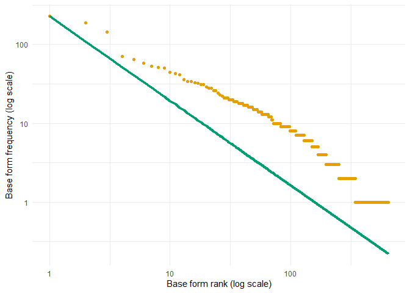

```r
# Fit the Zipfian distribution (log-log scale)
zipf_fit <- lm(log(Frequency) ~ log(FrequencyRank), data = baseform_freq)
alpha <- -coef(zipf_fit)[2] # Extract the slope, Zipf's alpha

# Generate the theoretical Zipfian distribution based on the fitted alpha
zipf_line <- data.frame(
  FrequencyRank = baseform_freq$FrequencyRank,
  PredictedFrequency = baseform_freq$Frequency[1] * (1 / baseform_freq$FrequencyRank)^alpha
)

# Create the plot
ggplot(baseform_freq, aes(x = FrequencyRank, y = Frequency)) +
  geom_point(color = colorBlindBlack8[2]) + # Data distribution
  geom_line(data = zipf_line, aes(x = FrequencyRank, y = PredictedFrequency),
            color = colorBlindBlack8[4],
            linewidth = 1.5) + # Zipfian distribution
  scale_x_log10() +
  scale_y_log10() +
  labs(#title = "Rank vs frequency (Log-Log scale)",
       x = "Base form rank (log scale)",
       y = "Base form frequency (log scale)") +
  theme_minimal()
```

```r
# Save the plot
ggsave(plot = last_plot(), filename = paste0(plots, "zipfsLaw.pdf"),
       width = 6, height = 4)
ggsave(plot = last_plot(), filename = paste0(plots, "zipfsLaw.jpg"),
       width = 6, height = 4)
ggsave(plot = last_plot(), filename = paste0(plots, "zipfsLaw.tif"),
       width = 6, height = 4, compression = "lzw", dpi = 600)
```

The plot does not follow entirely the Zipfian distribution.

Let us fit a simple Bayesian model to check whether the Zipfian distribution holds for the data.

```r
# Prepare the data
baseform_freq <- baseform_freq %>%
  mutate(logRank = log(FrequencyRank), logFreq = log(Frequency))

# Fit a Zipf's law model
zipf_model <- brm(
  logFreq ~ logRank,
  data = baseform_freq,
  family = gaussian(),
  prior = c(
    prior(normal(0, 10), class = "Intercept"),
    prior(normal(-1, 1), class = "b") # Prior for the slope (Zipf's alpha)
  ),
  iter = 2000, chains = 4, cores = 4,
  seed = 998,
  file = paste0(models, "zipf_model.rds")
)
zipf_model
```

```
##  Family: gaussian
##   Links: mu = identity; sigma = identity
## Formula: logFreq ~ logRank
##    Data: baseform_freq (Number of observations: 650)
##   Draws: 4 chains, each with iter = 2000; warmup = 1000; thin = 1;
##          total post-warmup draws = 4000
##
## Regression Coefficients:
##           Estimate Est.Error l-95% CI u-95% CI Rhat Bulk_ESS Tail_ESS
## Intercept     6.76      0.05     6.66     6.87 1.00     4095     3085
## logRank      -1.07      0.01    -1.09    -1.05 1.00     4083     3010
##
## Further Distributional Parameters:
##       Estimate Est.Error l-95% CI u-95% CI Rhat Bulk_ESS Tail_ESS
## sigma     0.24      0.01     0.23     0.25 1.00     4173     3056
##
## Draws were sampled using sampling(NUTS). For each parameter, Bulk_ESS
## and Tail_ESS are effective sample size measures, and Rhat is the potential
## scale reduction factor on split chains (at convergence, Rhat = 1).
```

```r
# Fit a null model (no rank effect)
zipf_null_model <- brm(
  logFreq ~ 1,
  data = baseform_freq,
  family = gaussian(),
  prior = prior(normal(0, 10), class = "Intercept"),
  iter = 2000, chains = 4, cores = 4,
  seed = 998,
  file = paste0(models, "zipf_null_model.rds")
)
zipf_null_model
```

```
##  Family: gaussian
##   Links: mu = identity; sigma = identity
## Formula: logFreq ~ 1
##    Data: baseform_freq (Number of observations: 650)
##   Draws: 4 chains, each with iter = 2000; warmup = 1000; thin = 1;
##          total post-warmup draws = 4000
##
## Regression Coefficients:
##           Estimate Est.Error l-95% CI u-95% CI Rhat Bulk_ESS Tail_ESS
## Intercept     0.88      0.04     0.80     0.97 1.00     3907     2564
##
## Further Distributional Parameters:
##       Estimate Est.Error l-95% CI u-95% CI Rhat Bulk_ESS Tail_ESS
## sigma     1.08      0.03     1.02     1.14 1.00     3804     2706
##
## Draws were sampled using sampling(NUTS). For each parameter, Bulk_ESS
## and Tail_ESS are effective sample size measures, and Rhat is the potential
## scale reduction factor on split chains (at convergence, Rhat = 1).
```

```r
# Compare the models with Bayes Factors
bayes_factor(zipf_model, zipf_null_model)
```

```
## Iteration: 1
## Iteration: 2
## Iteration: 3
## Iteration: 4
## Iteration: 5
## Iteration: 1
## Iteration: 2
## Iteration: 3
## Iteration: 4
```

```
## Estimated Bayes factor in favor of zipf_model over zipf_null_model:    Inf
```

The analysis explored whether the data follows a Zipfian distribution, where the frequency of an item is inversely proportional to its rank. The Bayesian model (`zipf_model`) demonstrated a strong relationship between log-transformed rank and log-transformed frequency, with a slope of -1.07 (95% CI: -1.09 to -1.05). This slope aligns closely with the expected value of -1 under Zipf’s law, providing strong evidence that the data exhibits a Zipfian-like behavior. The small estimated residual standard deviation ($\sigma=0.24$) indicates that the model explains most of the variability in the data.

A comparison with the null model (`zipf_null_model`), which assumes no effect of rank, resulted in an overwhelming Bayes Factor in favor of the Zipfian model ($BF=\infty$). This result underscores that the rank-frequency relationship is far stronger than would be expected under the null hypothesis.

The data points plotted above somewhat align with the Zipfian distribution line but do not perfectly follow it. This imperfection reflects the inherent variability and noise in real-world linguistic data, which rarely adheres perfectly to theoretical distributions. The small residual standard deviation supports that deviations from the Zipfian model are minor and primarily due to random noise or unmodeled factors. Such imperfections are common in natural datasets and do not undermine the overall finding that the data strongly supports a Zipfian distribution.

### Pareto principle

The Pareto Principle (also known as the 80/20 rule) suggests that roughly 80% of effects come from 20% of causes. For your data, this would mean checking if approximately 80% of the total frequency is contributed by 20% of the BaseForms.

```r
# Step 1: Calculate cumulative frequencies and percentages
pareto_data <- baseform_freq %>%
  arrange(desc(Frequency)) %>%
  mutate(
    CumulativeFrequency = cumsum(Frequency),
    CumulativePercentage = CumulativeFrequency / sum(Frequency) * 100,
    CumulativeBaseForms = row_number() / n() * 100
  )

# Step 2: Identify the percentage of BaseForms contributing to 80% of the total frequency
pareto_cutoff <- pareto_data %>%
  filter(CumulativePercentage >= 80) %>%
  slice(1)

percentage_of_baseforms <- pareto_cutoff$CumulativeBaseForms

# Print result
cat(sprintf("Approximately %.2f%% of the BaseForms contribute to 80%% of the total frequency.\n",
            percentage_of_baseforms))
```

```
## Approximately 27.54% of the BaseForms contribute to 80% of the total frequency.
```

Let us visualize the Lorenz curve: the cumulative percentage of frequency against the cumulative percentage of BaseForms.

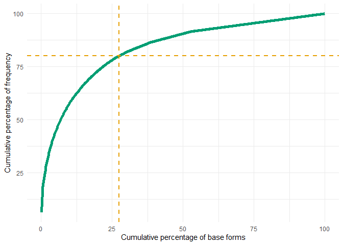

```r
ggplot(pareto_data, aes(x = CumulativeBaseForms, y = CumulativePercentage)) +
  geom_line(color = colorBlindBlack8[4], size = 2) +
  geom_vline(xintercept = percentage_of_baseforms, linetype = "dashed", color = colorBlindBlack8[2], linewidth = 1) +
  geom_hline(yintercept = 80, linetype = "dashed", color = colorBlindBlack8[2], linewidth = 1) +
  labs(
    #title = "Pareto Principle in Base Forms",
    x = "Cumulative percentage of base forms",
    y = "Cumulative percentage of frequency"
  ) +
  theme_minimal()
```

```r
# Save the plot
ggsave(plot = last_plot(), filename = paste0(plots, "paretoPrinciple.pdf"),
       width = 6, height = 4)
ggsave(plot = last_plot(), filename = paste0(plots, "paretoPrinciple.jpg"),
       width = 6, height = 4)
ggsave(plot = last_plot(), filename = paste0(plots, "paretoPrinciple.tif"),
       width = 6, height = 4, compression = "lzw", dpi = 600)
```

## Original language

Frequency of original languages.

```
## # A tibble: 19 × 2
##    OriginalLanguage Frequency
##    <chr>                <int>
##  1 German                2363
##  2 English                603
##  3 French                 313
##  4 Norwegian              103
##  5 Dutch                   98
##  6 Swedish                 95
##  7 Spanish                 19
##  8 Japanese                12
##  9 Polish                   6
## 10 Czech                    4
## 11 Hebrew                   4
## 12 Danish                   2
## 13 Korean                   2
## 14 Unknown                  2
## 15 Estonian                 1
## 16 Farsi                    1
## 17 Finnish                  1
## 18 Georgian                 1
## 19 Turkish                  1
```

How many base forms per original language?

```
## # A tibble: 19 × 2
##    OriginalLanguage DistinctBaseForms
##    <chr>                        <int>
##  1 German                         482
##  2 English                        234
##  3 French                          95
##  4 Dutch                           59
##  5 Swedish                         51
##  6 Norwegian                       30
##  7 Japanese                        12
##  8 Spanish                         12
##  9 Polish                           6
## 10 Czech                            4
## 11 Hebrew                           4
## 12 Danish                           2
## 13 Korean                           2
## 14 Estonian                         1
## 15 Farsi                            1
## 16 Finnish                          1
## 17 Georgian                         1
## 18 Turkish                          1
## 19 Unknown                          1
```

How many base forms per book per original language? (a little bit more objective than the one above)

```
## # A tibble: 19 × 4
##    OriginalLanguage TotalBooks DistinctBaseForms BaseFormsPerBook
##    <chr>                 <int>             <int>            <dbl>
##  1 Norwegian                 3                30            10
##  2 Japanese                  2                12             6
##  3 Polish                    1                 6             6
##  4 Czech                     1                 4             4
##  5 Hebrew                    1                 4             4
##  6 Spanish                   3                12             4
##  7 Swedish                  13                51             3.92
##  8 French                   25                95             3.8
##  9 Dutch                    16                59             3.69
## 10 English                  88               234             2.66
## 11 Danish                    1                 2             2
## 12 Korean                    1                 2             2
## 13 German                  270               482             1.79
## 14 Estonian                  1                 1             1
## 15 Farsi                     1                 1             1
## 16 Finnish                   1                 1             1
## 17 Georgian                  1                 1             1
## 18 Turkish                   1                 1             1
## 19 Unknown                   1                 1             1
```

Let us plot it.

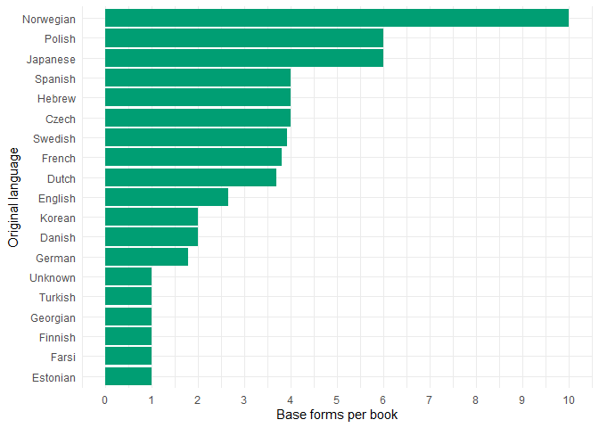

## Words per book

How many words in a book are ideophones?

```
## # A tibble: 6 × 5
##   BookTitle                   AgeGroup TotalWords Ideophones IdeophonePercentage
##   <chr>                          <int>      <int>      <int>               <dbl>
## 1 Alfonso der Meisterdieb. 9…        1          1          1                 100
## 2 Ganz weit weg                      1          2          2                 100
## 3 Guck gack ga! Wer kommt de…        1          1          1                 100
## 4 Hatschi!                           1          1          1                 100
## 5 Lieblingstiere am Meer             1         12         12                 100
## 6 Paulinchen Mutkaninchen            1          2          2                 100
```

```
## # A tibble: 20 × 5
##    BookTitle                  AgeGroup TotalWords Ideophones IdeophonePercentage
##    <chr>                         <int>      <int>      <int>               <dbl>
##  1 Alfonso der Meisterdieb. …        1          1          1               100
##  2 Ganz weit weg                     1          2          2               100
##  3 Guck gack ga! Wer kommt d…        1          1          1               100
##  4 Hatschi!                          1          1          1               100
##  5 Lieblingstiere am Meer            1         12         12               100
##  6 Paulinchen Mutkaninchen           1          2          2               100
##  7 Zwei für mich, einer für …        1          1          1               100
##  8 Du piepst doch nicht rich…        1         31         20                64.5
##  9 Ist da ein Freund?                1         17         10                58.8
## 10 Die kleine Gans, die aus …        1        237        131                55.3
## 11 Tom und Timmi... richtig …        1         33         14                42.4
## 12 Paul, das Schlafschaf             1         10          4                40
## 13 Kleine Eule ganz allein           1         13          5                38.5
## 14 Schhh… Das Buch vom Schlaf        1          8          3                37.5
## 15 Spriedel                          1        112         39                34.8
## 16 Vier kleine Piraten               1         12          4                33.3
## 17 Mouk hat Langeweile               1        109         33                30.3
## 18 Lulu liebt Lesen                  1         14          4                28.6
## 19 Die Hugis. Der neue Pullo…        1         37         10                27.0
## 20 Bäumchen, verwandle dich!         1         19          5                26.3
```

Do books with more words tend to have more ideophones in them?

```
## Bayes factor analysis
## --------------
## [1] Alt., r=0.707 : 6.370117e+40 ±0%
##
## Against denominator:
##   Null, rho = 0
## ---
## Bayes factor type: BFcorrelation, Jeffreys-beta*
```

With $BF_{10}=6.370117×10^{40}$ there is very strong evidence for a correlation between a total word count and the number of ideophones.

Let us visualize the correlation.

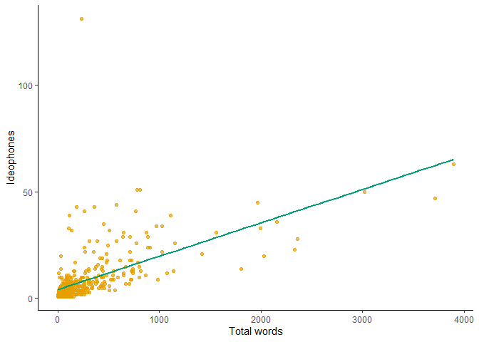

## Number of ideophone per age group

How does the amount of words that are ideophones depend on age group?

```
## # A tibble: 2 × 4
##   AgeGroup AvgTotalWords AvgIdeophones AvgIdeophonePercentage
##      <int>         <dbl>         <dbl>                  <dbl>
## 1        1          185.          7.16                   8.42
## 2        2          613.         13.3                    3.44
```

In descriptive means, there are less total words in the age group 1, but the mean ideophone percentage is higher.

Let us visualize the number of words per age group.

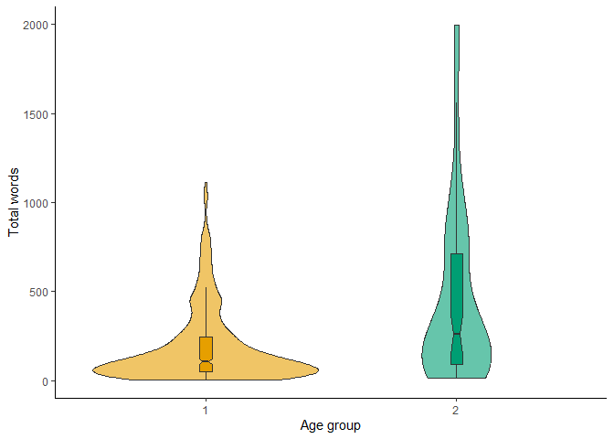

Let us visualize the number of ideophones per age group.

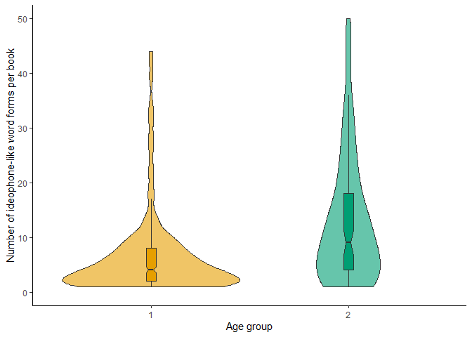

There are more ideophones per book by age group. But let us see whether that holds if we normalize for overall word count, i.e., by looking at percentages.

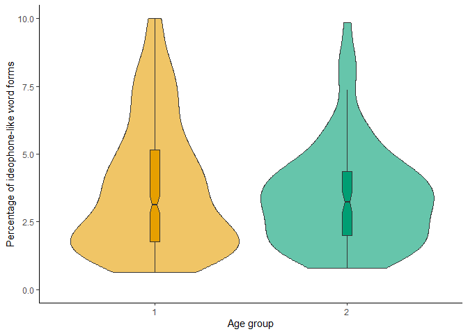

There is not really a difference in the box plot.

Let’s see whether this can be tested in Bayes Factor. (In the dissertation I used a t-test.)

```
## Bayes factor analysis
## --------------
## [1] Alt., r=0.707 : 8.766687 ±0%
##
## Against denominator:
##   Null, mu1-mu2 = 0
## ---
## Bayes factor type: BFindepSample, JZS
```

```
## Bayes factor analysis
## --------------
## [1] Alt., r=0.5 : 10.46193 ±0%
##
## Against denominator:
##   Null, mu1-mu2 = 0
## ---
## Bayes factor type: BFindepSample, JZS
```

```
## Bayes factor analysis
## --------------
## [1] Alt., r=0.2 : 11.11552 ±0%
##
## Against denominator:
##   Null, mu1-mu2 = 0
## ---
## Bayes factor type: BFindepSample, JZS
```

The effect observed here is weak, but given the imbalance in the number of data points between the groups, cf.

```
## # A tibble: 2 × 2
##   AgeGroup NumberOfBooks
##      <int>         <int>
## 1        1           342
## 2        2            89
```

and that group 1 consists of books for children from 0 to 6 years old, a much wider gap than group 2, with books for kids between 7 and 9, it is still impressive that any effect can be found.

## Ideophone diversity per age group

How many unique ideophones are there per age group?

```
## # A tibble: 2 × 2
##   AgeGroup UniqueIdeophones
##      <int>            <int>
## 1        1              856
## 2        2              333
```

How many base forms are there per age group?

```
## # A tibble: 2 × 2
##   AgeGroup BaseForms
##      <int>     <int>
## 1        1       572
## 2        2       239
```

### Per book normalization

But we need to take into account that the number of books differs, so let us look at the number of unique ideophones/base forms per book per age group.

```
## # A tibble: 2 × 6
##   AgeGroup TotalBooks UniqueIdeophones BaseForms IdeophonesPerBook
##      <int>      <int>            <int>     <int>             <dbl>
## 1        1        342              856       572              2.50
## 2        2         89              333       239              3.74
## # ℹ 1 more variable: BaseFormsPerBook <dbl>
```

Let us plot the ideophones first.

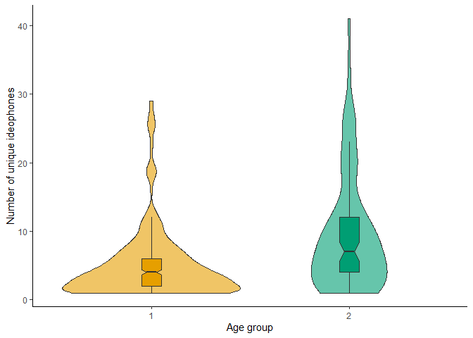

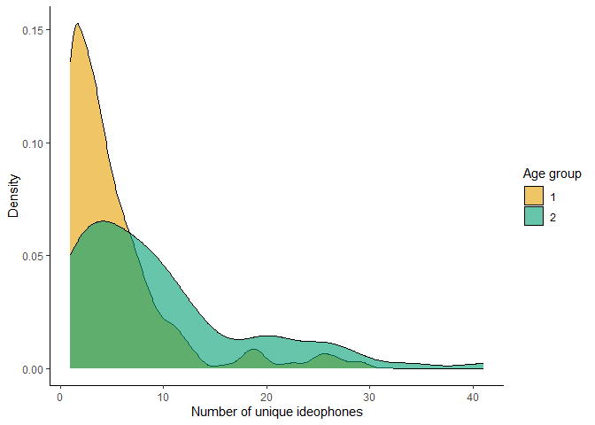

And now the base forms.

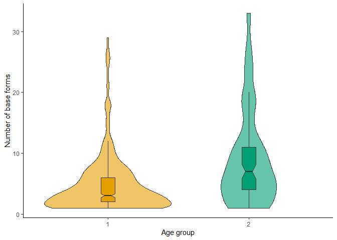

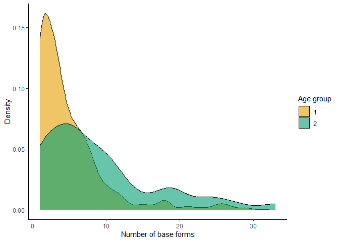

### Per page normalization

We will also look at the number of pages.

Make a dataframe for total ideophones per book and ideophones per page. Then, calculate average ideophones per page for each age group.

```
## # A tibble: 2 × 6
##   AgeGroup AvgIdeophonesPerPage MedianIdeophonesPerPage SD_IdeophonesPerPage
##      <int>                <dbl>                   <dbl>                <dbl>
## 1        1                0.737                   0.344                0.928
## 2        2                0.328                   0.286                0.200
## # ℹ 2 more variables: TotalBooks <int>, .groups <chr>
```

Now we plot unique ideophones per page by age group.

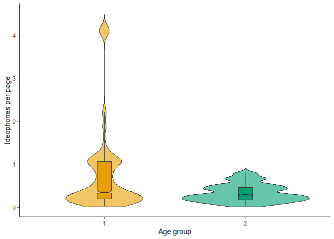

Remove missing values for Bayesian t-test.

Perform a Bayesian t-test to see if the difference between age groups is statistically meaningful.

```
## Bayes factor analysis
## --------------
## [1] Alt., r=0.707 : 4.102993e+45 ±0%
##
## Against denominator:
##   Null, mu1-mu2 = 0
## ---
## Bayes factor type: BFindepSample, JZS
```

Even though the plot above does not look as if there was an effect, Bayes Factor $BF_{10}=4.1×10^{45}$ is extremely high and confirms a large difference between the age groups in ideophones per page.

Analyze the relationship between page count and ideophones per page. Let’s visualize the correlation.

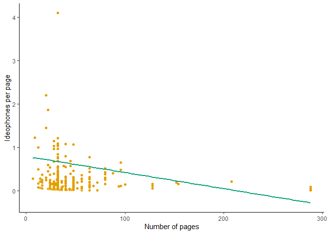

The visualization clearly shows that books that have more pages tend to have less ideophones per page.

```
## Bayes factor analysis
## --------------
## [1] Alt., r=0.707 : 1.101292e+32 ±0%
##
## Against denominator:
##   Null, rho = 0
## ---
## Bayes factor type: BFcorrelation, Jeffreys-beta*
```

The correlation between `PageCount` and `IdeophonesPerPage` is very strong with $BF_{10}=1.101292×10^{32}$.

If we look at the different age groups, will there be a different correlation?

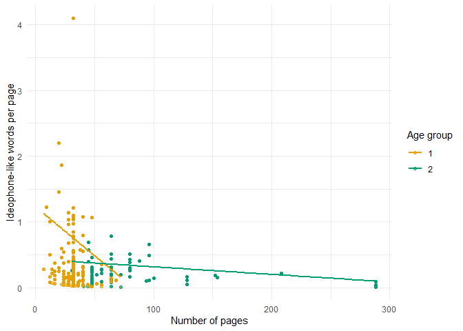

It is clearly visible that age group 1 has an extremely steep correlation, while age group 2 a rather flat one. Let us examine this statistically.

```
## Bayes factor analysis
## --------------
## [1] Alt., r=0.707 : 4.102993e+45 ±0%
##
## Against denominator:
##   Null, mu1-mu2 = 0
## ---
## Bayes factor type: BFindepSample, JZS
```

The $BF_{10}=4.1×10^{45}$ provides overwhelming evidence that ideophones per page differ across age groups.

# Export cleaned dataset

Export cleaned dataset to `german_ideophone_dataset.csv`.

```r
write.csv(df, paste0(data, "german_ideophone_dataset.csv"), row.names = FALSE)
```

This concludes this exploration.

# References

Ćwiek, Aleksandra. 2022. “Iconicity in Language and Speech.” PhD thesis, Berlin. https://doi.org/10.18452/24544.

Dingemanse, Mark. 2012a. “Advances in the Cross-Linguistic Study of Ideophones.” *Language and Linguistics Compass* 6 (10): 654672. https://doi.org/10.1002/lnc3.361.

———. 2012b. “Advances in the Cross-Linguistic Study of Ideophones.” *Language and Linguistics Compass* 6 (10): 654672. https://doi.org/10.1002/lnc3.361.

———. 2017. “Expressiveness and System Integration: On the Typology of Ideophones, with Special Reference to Siwu.” *STUF – Language Typology and Universals* 70 (2): 363384. https://doi.org/10.1515/stuf-2017-0018.

———. 2019. “Chapter 1. ‘Ideophone’ as a Comparative Concept.” In, edited by Kimi Akita and Prashant Pardeshi, 16:13–33. Amsterdam: John Benjamins Publishing Company. https://doi.org/10.1075/ill.16.02din.

Dingemanse, Mark, and Kimi Akita. 2016. “An Inverse Relation Between Expressiveness and Grammatical Integration: On the Morphosyntactic Typology of Ideophones, with Special Reference to Japanese.” *Journal of Linguistics* 53 (03): 501532. https://doi.org/10.1017/s002222671600030x.

“DWDS Digitales Wörterbuch der deutschen Sprache.” n.d. https://www.dwds.de/d/korpora/webxl.

McLean, Bonnie. 2020. “Revising an Implicational Hierarchy for the Meanings of Ideophones, with Special Reference to Japonic.” *Linguistic Typology* -1 (ahead-of-print). https://doi.org/10.1515/lingty-2020-2063.